# Bulk RNA-seq pipeline part 2 - Visulaization of data with volcano plots and heatmaps

2024-05-08

# 1. Introduction

This module will pick up from the previous module where we performed DE analysis with DESeq2. I’ve tried to set the modules up so that they can be used independently if you want. In this module, we’ll go over making volcano plots and heat maps. First, we need to load the packages we’re going to use. Then, we will need to load up the data tables we exported in the previous module as dataframes to work with here.

# 2. Load and compile dependencies and set working directory

Similar to part 1, we first want to load all of the software packages that we’ll use and set the working directory to read from. As in part 1, the code here will check whether a package is installed and, if not, install it. We’ll be using functions within the *tidyverse* to build our volcano plot and heatmap. Note that these are NOT Bioconductor packages and are, thus, loaded using the standard R installer.

Package installation:

```r
packages<-c("tidyverse", "RColorBrewer", "ggrepel")
installed<- packages %in% rownames(installed.packages())

if (any(installed == FALSE)) {
  install.packages(!installed)
}

library(tidyverse) # includes ggplot2, for data visualisation. dplyr, for data manipulation.
library(RColorBrewer) # for a colourful plot
library(ggrepel) # for nice annotations
```

Set working directory:

```r
knitr::opts_knit$set(root.dir = '/Users/aaron/Dropbox (Personal)/Protocols/Bioinformatics/Bioinformatics_Scripts_From_Aaron/Bioinformatics Resources/')
```

# 3. Import the gene tables

```r
de_matrix<-read.table("de_gene_matrix.txt", header=TRUE)
res_total_lfc1_padj005<-read.table("de_genes_lfc1_padj005.txt", header = TRUE)
norm_counts<-read.table("normalized_counts.txt", header=TRUE)
```

# 4. Make a volcano plot of the DE gene set

### 4.1 Set thresholds for differntiall expression

First, we’ll add a column to table designating whether the gene is differentially expressed and, if so, if it is up or down-regulated.

```r
de_matrix$diffexpressed <- "NO"
de_matrix$diffexpressed[de_matrix$log2FoldChange >= 1 & de_matrix$padj <= 0.05] <- "UP"
de_matrix$diffexpressed[de_matrix$log2FoldChange <= -1 & de_matrix$padj <= 0.05] <- "DOWN"
```

### 4.2 Extract genes of interest (optional)

For this volcano plot, we want to label points of particular genes of interest. To do this we will read in our list of genes from a file and make new column in the dataframe with them.

The list is in a text file called “interesting_genes.txt” and we will read it in using read_lines since the genes are in rows. If you have a list of genes where they are in a tab- or comma-separated (.txt, .tsv, or .csv) document with each gene in the column, instead use the read.csv function instead and set the appropriate delimiter.

```r
interesting_genes<-read_lines("/Users/aaron/Dropbox/Protocols/Bioinformatics/Bioinformatics_Scripts_From_Aaron/Bioinformatics Resources/interesting_genes.txt")

interesting_genes ## peek and check that your list is in the appropriate format
```

```
##  [1] "AMTN"    "ODAM"    "APOE"    "TIMP3"   "EFEMP1"  "CNQTNF5" "UNC13D"
##  [8] "ATP2B2"  "SCD1"    "SLC13A3" "CCN2"    "MXRA5"   "TF"      "LRP8"
```

Next, we will make an abbreviated data frame of just these genes.

```r
sig_genes <- de_matrix %>%
  filter(symbol %in% interesting_genes) ## make a dataframe of just the interesting genes

sig_genes ## check the output to confirm its in the appropriate format
```

```
##      baseMean log2FoldChange     lfcSE       stat       pvalue         padj
## 1   33956.436     -4.3042451 0.3014400 -14.278943 2.960570e-46 1.838950e-43
## 2   12491.669     -3.1746771 0.2354563 -13.483083 1.967119e-41 8.839061e-39
## 3  570000.091      0.9549403 0.1268847   7.526045 5.230024e-14 1.407043e-12
## 4   19225.903      2.7671743 0.4781842   5.786838 7.172388e-09 8.443348e-08
## 5    5458.339      4.4103046 0.5399598   8.167838 3.139652e-16 1.175644e-14
## 6  180481.648      1.7599103 0.1226100  14.353723 1.009675e-46 6.461613e-44
## 7   28819.406      2.3916526 0.2179730  10.972242 5.196747e-28 6.902522e-26
## 8   13252.322     -1.4290210 0.2572974  -5.553965 2.792610e-08 2.905278e-07
## 9    7230.000     -3.1188224 0.2605686 -11.969294 5.146442e-33 1.055220e-30
## 10   7348.127     -2.1412475 0.1863079 -11.493055 1.429645e-30 2.358803e-28
## 11   3954.095     -1.4064260 0.1391262 -10.108998 5.039691e-24 4.502265e-22
## 12  21913.790      6.0685857 0.7729579   7.851121 4.123360e-15 1.316089e-13
##           ensembl_var         ensembl  symbol entrez diffexpressed
## 1  ENSG00000091513.16 ENSG00000091513      TF   7018          DOWN
## 2  ENSG00000092929.12 ENSG00000092929  UNC13D 201294          DOWN
## 3  ENSG00000100234.12 ENSG00000100234   TIMP3   7078            NO
## 4   ENSG00000101825.8 ENSG00000101825   MXRA5  25878            UP
## 5  ENSG00000109205.17 ENSG00000109205    ODAM  54959            UP
## 6  ENSG00000115380.20 ENSG00000115380  EFEMP1   2202            UP
## 7   ENSG00000118523.6 ENSG00000118523    CCN2   1490            UP
## 8  ENSG00000130203.10 ENSG00000130203    APOE    348          DOWN
## 9  ENSG00000157087.20 ENSG00000157087  ATP2B2    491          DOWN
## 10 ENSG00000157193.18 ENSG00000157193    LRP8   7804          DOWN
## 11 ENSG00000158296.14 ENSG00000158296 SLC13A3  64849          DOWN
## 12 ENSG00000187689.10 ENSG00000187689    AMTN 401138            UP
```

### 4.3 Construct the volcano plot

Now we can construct our volcano plot and use the objects we set up in parts 4.1 and 4.2 to label and annotate it.

First, set up a color scheme. This is optional as ggplot has a default scheme. But, setting up your own allows you to have more control over the appearance.

```r
cols <- c("UP" = "red", "DOWN" = "blue", "NO" = "grey") ## The color scheme is set to label points based on the value in the diffexpressed column which we set up in part 4.1.
```

Now, generate the plot. Each annotation function is described in the comments to the right:

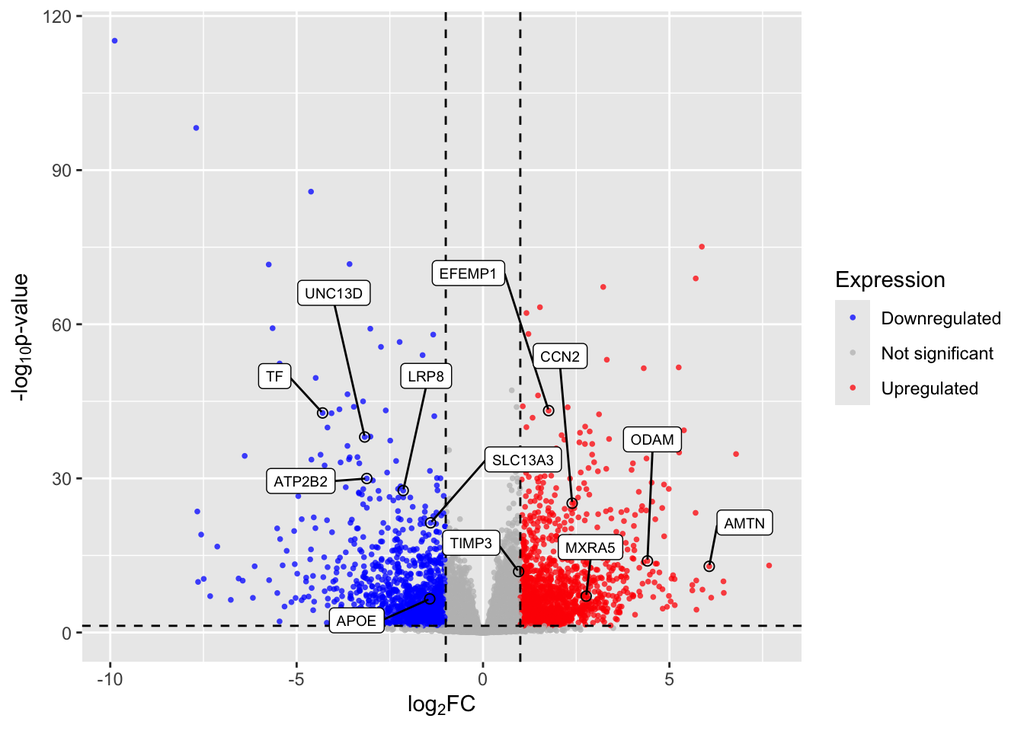

```r
volcano<-ggplot(data = de_matrix,
                aes(x = log2FoldChange,
                    y = -log10(padj))) +
  geom_point(aes(colour = diffexpressed), ## the points will be colored different based on the value in the diffexpressed column. This uses the default color scheme but we will override that with the scale_color_manual function below.
             alpha = 0.75,
             shape = 16,
             size = 1) +
  geom_point(data = sig_genes, ## this well draw a circle around points that correspond to our genes of interest.
             shape = 21,
             size = 2,
             colour = "black") +
  geom_vline(xintercept = c(-1, 1), ## draws the vertical line showing the thresholds for log2FC
             col = "black",
             linetype = 'dashed') +
  geom_hline(yintercept = -log10(0.05), ## draws the horizontal line showing the threshold for adjusted p value
             col = "black",
             linetype = 'dashed') +
  scale_color_manual(values = cols, ## this overrides the color scheme from above and labels the legend
                     labels = c("Downregulated", "Not significant", "Upregulated")) +
  labs(colour = 'Expression', ## labels the axes
       x = expression("log"[2]*"FC"),
       y = expression("-log"[10]*"p-value")) +
  geom_label_repel(data = sig_genes,
                   ## labels the points of genes of interest. The geom_label_repel function attempts to arrange the labels so that they are easily viewed on the plot.,
                   size = 2.5,
                   aes(label = symbol),
                   box.padding = 1,
                   force = 2,
                   nudge_y = 3,
                   show.legend = FALSE)
volcano
```

The image shown here may vary from the the actual volcano plot that you export. The following code will export as a PDF which can be further manipulated in Illustrator if necessary.

```r
pdf("volcano.pdf", width = 10, height = 13)
plot(volcano)
invisible(dev.off())
```

# 5. Make a heat map

Now we’ll make a heat map of all the genes. This is simply just another way to visualize how the genes are expressed between the groups. There are a number of different packages you can use to make heatmaps but R’s *heatmap* function is simple and really useful for simple visualization.

First, we have to convert the normalized counts object into a numeric matrix. We then use the heatmap function in the base R to make the heatmap.

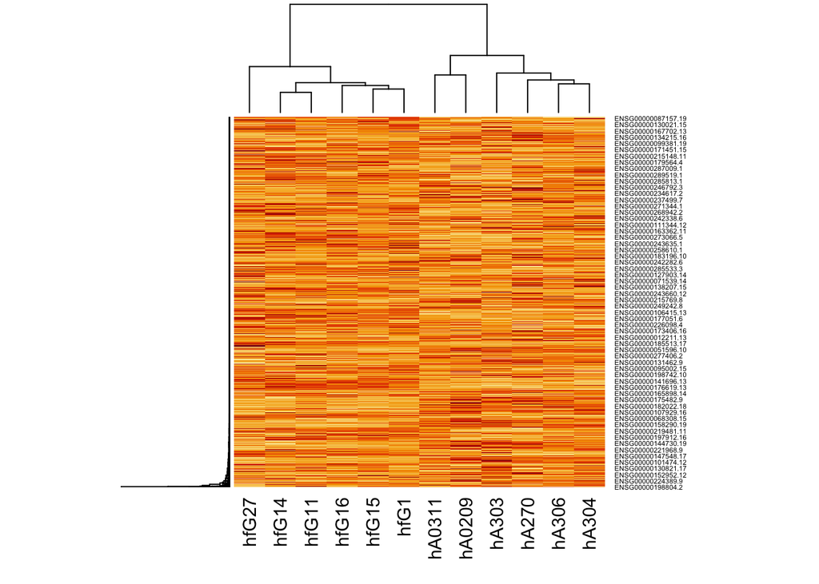

```r
mat <- data.matrix(norm_counts)

heatmap(mat, scale="row", na.rm=TRUE)
```

```r
## Here, we've scaled the colorization on the row which is the gene. It's a sort of normalization to account for the distribution of the counts across all of the genes.
```

```r
pdf("heatmap.pdf", width = 10, height = 13)
heatmap(mat, scale="row", na.rm=TRUE)
invisible(dev.off())
```

By default, the R heatmap function performs heriarchial clustering (this can be turned off if you want to retain the structure of the matrix in the heatmap.

We can see that the fetal and adult samples cluster together but the clustering for the genes is less obvious. There are definitely areas that are “opposing” but it’s likely that most of the variation falls into a relatively small group of genes.

As mentioned above, there are a number of tools to generate a heatmap. Some of these other tools are more optimal for sequencing data and are really useful when you want to have more control over the parameters. But for simply graphing the entire gene set, the base R heatmap function is fine.

# Next steps

Now that we have some basic renderings of the data, we can start to tease out the interesting parts of the data set. Next, we’ll go over gene ontology and pathway analysis to identify mechanisms involved with our DE genes using both standard enrichment and gene set enrichment analysis (GSEA).